# DATOS 2007

```r
library(rio)
urb_2007=import('https://github.com/Samanta-Rivera/EPAP2-Proyecto/raw/master/DATA/Urbanizacion_Censo_2007.xlsx')
```

```
## * `` -> ...2
## * `` -> ...3
## * `` -> ...4
## * `` -> ...5
## * `` -> ...6
## * … and 6 more problems
```

```r
urb_2007=urb_2007[,c(2,3,8,10)]
urb_2007=urb_2007[-c(1:3),]
names(urb_2007)=c('Region','Province','Total_Pop','Rural_Pop')
rownames(urb_2007)=NULL
```

```r
library(stringi)
urb_2007$Region=stri_trans_general(str = urb_2007$Region, id = "Latin-ASCII")
urb_2007$Province=stri_trans_general(str = urb_2007$Province, id = "Latin-ASCII")
```

```r
inter_2007=import('https://github.com/Samanta-Rivera/EPAP2-Proyecto/raw/master/DATA/Internet_Censo_2007.xlsx')
```

```
## * `` -> ...2
## * `` -> ...3
## * `` -> ...4
## * `` -> ...5
## * `` -> ...6
## * … and 4 more problems
```

```r
inter_2007=inter_2007[,c(2,3,8)]
inter_2007=inter_2007[-c(1:3),]
names(inter_2007)=c('Region','Province','Inter_Porc')
rownames(inter_2007)=NULL
```

```r
inter_2007$Region=stri_trans_general(str = inter_2007$Region, id = "Latin-ASCII")
inter_2007$Province=stri_trans_general(str = inter_2007$Province, id = "Latin-ASCII")
```

```r
idh_2007=import('https://github.com/Samanta-Rivera/EPAP2-Proyecto/raw/master/DATA/IDH_PNUD2007.xlsx')
```

```
## * `` -> ...2
## * `` -> ...3
## * `` -> ...4
## * `` -> ...5
## * `` -> ...6
## * … and 11 more problems
```

```r
idh_2007[,-c(1,2,3,10,12,14,16)]=NULL
idh_2007=idh_2007[c(8:2256),]
names(idh_2007)=c("Ubigeo",'Region','Province','LifeHope','CompSecEdu','EduYears','IncFamPPC')
idh_2007[,c(4:7)]=lapply(idh_2007[,c(4:7)],as.numeric)
```

```r
list_idh_2007=as.list(idh_2007[,1])
provinces_2007=grep(pattern='[0-9]{1}[0-9]{1}[0-9]{1}[0-9]{1}[0]{1}[0]{1}',x=list_idh_2007)
idh_2007=idh_2007[c(provinces_2007),]
row.names(idh_2007)=NULL
```

```r
idh_2007$Region[2:8]='Amazonas'
idh_2007$Region[10:29]='Ancash'
idh_2007$Region[31:37]='Apurimac'
idh_2007$Region[39:46]='Arequipa'
idh_2007$Region[48:58]='Ayacucho'
idh_2007$Region[60:72]='Cajamarca'
idh_2007$Region[73]='Callao'
idh_2007$Region[75:87]='Cusco'
idh_2007$Region[89:95]='Huancavelica'
idh_2007$Region[97:107]='Huanuco'
idh_2007$Region[109:113]='Ica'
idh_2007$Region[115:123]='Junin'
idh_2007$Region[125:136]='La Libertad'
idh_2007$Region[138:140]='Lambayeque'
idh_2007$Region[142:151]='Lima'
idh_2007$Region[153:159]='Loreto'
idh_2007$Region[161:163]='Madre De Dios'
idh_2007$Region[165:167]='Moquegua'
idh_2007$Region[169:171]='Pasco'
idh_2007$Region[173:180]='Piura'
idh_2007$Region[182:194]='Puno'
idh_2007$Region[196:205]='San Martin'
idh_2007$Region[207:210]='Tacna'
idh_2007$Region[212:214]='Tumbes'
idh_2007$Region[216:219]='Ucayali'
```

```r
idh_2007=na.omit(idh_2007)
row.names(idh_2007)=NULL
```

```r
library(stringi)
idh_2007$Region=stri_trans_general(str = idh_2007$Region, id = "Latin-ASCII")
idh_2007$Province=stri_trans_general(str = idh_2007$Province, id = "Latin-ASCII")
```

```r
idh_2007$Prov_Name=paste0(idh_2007$Region,idh_2007$Province)
idh_2007[,c(2,3)]=NULL
```

# DATOS 2017

```r
urb_raw=import('https://github.com/Samanta-Rivera/EPAP2-Proyecto/raw/master/DATA/URBANIZACION_CENSO_2017.xlsx')
```

```
## * `` -> ...2
## * `` -> ...3
## * `` -> ...4
## * `` -> ...5
```

```r
urb_raw=urb_raw[,c(2:4)]
urb_raw=urb_raw[c(7:1360),]
row.names(urb_raw)=NULL
names(urb_raw)=c('1','2','3')
```

```r
ubi_urb=grep('AREA', x=urb_raw$`1`)
provname_urb=grep('prov',x=urb_raw$`2`)
provnames_2_urb=grep('Prov',x=urb_raw$`2`)
rural_urb=grep('Rural',x=urb_raw$`1`)
```

```r
urb_2017=data.frame(urb_raw$`1`[c(ubi_urb)])
urb_2017=urb_2017[-67,]
urb_2017=as.data.frame(urb_2017)
urb_2017$Name=urb_raw$`2`[c(provname_urb)]
urb_2017$Rur=urb_raw$`3`[c(rural_urb)]
names(urb_2017)=c('Ubigeo','Name','Rural_Porc')
```

```r
library(readr)
library(stringr)
urb_2017[,1]=str_split(urb_2017[,1],
                         pattern = '#',
                         simplify = T)[,2]
urb_2017[,1]=trimws(urb_2017[,1],whitespace = "[\\h\\v]")
urb_2017[,1]=paste0(urb_2017[,1],'00')
urb_2017$Region=str_split(urb_2017[,2],
                         pattern = ',',
                         simplify = T)[,1]
urb_2017$Province=str_split(urb_2017[,2],
                         pattern = ':',
                         simplify = T)[,2]
urb_2017=urb_2017[,-2]
urb_2017$Province[145:147]=str_split(urb_2017$Region[145:147],'de ', simplify=T)[,3]
urb_2017$Region[145:147]=str_split(urb_2017$Region[145:147],'prov', simplify=T)[,1]
urb_2017[196,]=c('070100',0,'Callao','Callao')
urb_2017[,c(3,4)]=lapply(urb_2017[,c(3,4)],trimws,whitespace = "[\\h\\v]")
urb_2017[,2]=as.numeric(urb_2017[,2])
```

```r
urb_2017$Region=stri_trans_general(str = urb_2017$Region, id = "Latin-ASCII")
urb_2017$Province=stri_trans_general(str = urb_2017$Province, id = "Latin-ASCII")
urb_2017[,3]=gsub('La Lbertad','La Libertad',urb_2017[,3])
```

```r
inter_raw=import('https://github.com/Samanta-Rivera/EPAP2-Proyecto/raw/master/DATA/INTERNET_CESNO_2017.xlsx')
```

```
## * `` -> ...2
## * `` -> ...3
## * `` -> ...4
## * `` -> ...5
```

```r
inter_raw=inter_raw[,c(2:5)]
inter_raw=inter_raw[c(9:1379),]
row.names(inter_raw)=NULL
names(inter_raw)=c('1','2','3','4')
```

```r
ubi_inter=grep('AREA', x=inter_raw$`1`)
provname_inter=grep('prov',x=inter_raw$`2`)
provname_2_inter=grep('Prov',x=inter_raw$`2`)
internet_inter=grep('Sí',x=inter_raw$`1`)
internet_inter=internet_inter[-67]
```

```r
inter_2017=data.frame(inter_raw$`1`[c(ubi_inter)])
inter_2017=inter_2017[-67,]
inter_2017=as.data.frame(inter_2017)
inter_2017$Name=inter_raw$`2`[c(provname_inter)]
inter_2017$Internet=inter_raw$`4`[c(internet_inter)]
names(inter_2017)=c('Ubigeo','Name','Inter_Porc')
```

```r
inter_2017[,1]=str_split(inter_2017[,1],
                         pattern = '#',
                         simplify = T)[,2]
inter_2017[,1]=trimws(inter_2017[,1],whitespace = "[\\h\\v]")
inter_2017[,1]=paste0(inter_2017[,1],'00')
inter_2017$Region=str_split(inter_2017[,2],
                         pattern = ',',
                         simplify = T)[,1]
inter_2017$Province=str_split(inter_2017[,2],
                         pattern = ':',
                         simplify = T)[,2]
inter_2017=inter_2017[,-2]
inter_2017$Province[145:147]=str_split(inter_2017$Region[145:147],'de ', simplify=T)[,3]
inter_2017$Region[145:147]=str_split(inter_2017$Region[145:147],'prov', simplify=T)[,1]
inter_2017[196,]=c('070100',0.442060940246706,'Callao','Callao')
inter_2017[,c(3,4)]=lapply(inter_2017[,c(3,4)],trimws,whitespace = "[\\h\\v]")
inter_2017[,2]=as.numeric(inter_2017[,2])
```

```r
inter_2017$Region=stri_trans_general(str = inter_2017$Region, id = "Latin-ASCII")
inter_2017$Province=stri_trans_general(str = inter_2017$Province, id = "Latin-ASCII")
inter_2017[,3]=gsub('La Lbertad','La Libertad',inter_2017[,3])
```

# IDH 2012

```r
idh_2012=import('https://github.com/Samanta-Rivera/EPAP2-Proyecto/raw/master/DATA/IDH_PNUD2012.xlsx')
```

```
## * `` -> ...2
## * `` -> ...3
## * `` -> ...4
## * `` -> ...5
## * `` -> ...6
## * … and 11 more problems
```

```r
idh_2012[,-c(1,2,3,10,12,14,16)]=NULL
idh_2012=idh_2012[c(8:2257),]
names(idh_2012)=c("Ubigeo",'Region','Province','LifeHope','CompSecEdu','EduYears','IncFamPPC')
idh_2012[,c(4:7)]=lapply(idh_2012[,c(4:7)],as.numeric)
```

```r
list_idh_2012=as.list(idh_2012[,1])
provinces_2012=grep(pattern='[0-9]{1}[0-9]{1}[0-9]{1}[0-9]{1}[0]{1}[0]{1}',x=list_idh_2012)
idh_2012=idh_2012[c(provinces_2012),]
row.names(idh_2012)=NULL
```

```r
idh_2012$Region[2:8]='Amazonas'
idh_2012$Region[10:29]='Ancash'
idh_2012$Region[31:37]='Apurimac'
idh_2012$Region[39:46]='Arequipa'
idh_2012$Region[48:58]='Ayacucho'
idh_2012$Region[60:72]='Cajamarca'
idh_2012$Region[73]='Callao'
idh_2012$Region[75:87]='Cusco'
idh_2012$Region[89:95]='Huancavelica'
idh_2012$Region[97:107]='Huanuco'
idh_2012$Region[109:113]='Ica'
idh_2012$Region[115:123]='Junin'
idh_2012$Region[125:136]='La Libertad'
idh_2012$Region[138:140]='Lambayeque'
idh_2012$Region[142:151]='Lima'
idh_2012$Region[153:159]='Loreto'
idh_2012$Region[161:163]='Madre De Dios'
idh_2012$Region[165:167]='Moquegua'
idh_2012$Region[169:171]='Pasco'
idh_2012$Region[173:180]='Piura'
idh_2012$Region[182:194]='Puno'
idh_2012$Region[196:205]='San Martin'
idh_2012$Region[207:210]='Tacna'
idh_2012$Region[212:214]='Tumbes'
idh_2012$Region[216:219]='Ucayali'
```

```r
idh_2012=na.omit(idh_2012)
row.names(idh_2012)=NULL
```

```r
idh_2012$Region=stri_trans_general(str = idh_2012$Region, id = "Latin-ASCII")
idh_2012$Province=stri_trans_general(str = idh_2012$Province, id = "Latin-ASCII")
```

```r
idh_2012$Prov_Name=paste0(idh_2012$Region,idh_2012$Province)
idh_2012[,c(2,3)]=NULL
```

# Creación de las tablas

```r
urb_2007[,c(3,4)]=lapply(urb_2007[,c(3,4)],as.numeric)
urb_2007$Rur_Porc <- urb_2007$Rural_Pop / urb_2007$Total_Pop
urb_2007[,c(3,4)]=NULL
```

```r
inter_2007$Region=NULL
```

```r
Data2007=merge(urb_2007, inter_2007)
Data2007$Prov_Name=paste0(Data2007$Region,Data2007$Province)
Data2007=Data2007[,c(3:5)]
```

```r
Data2007=merge(Data2007,idh_2007)
Data2007$Code=Data2007$Ubigeo
Data2007$Ubigeo=NULL
```

```r
Data2007[,c(2:7)]=lapply(Data2007[,c(2:7)],as.numeric)
```

```r
inter_2017$Region=NULL
```

```r
Data2017=merge(urb_2017, inter_2017)
Data2017$Prov_Name=paste0(Data2017$Region,Data2017$Province)
Data2017[,c(1,2,4)]=NULL
```

```r
Data2017=merge(Data2017,idh_2012)
Data2017$Code=Data2017$Ubigeo
Data2017$Ubigeo=NULL
```

# Limpieza del entorno

```r
rm(idh_2007)
rm(idh_2012)
rm(inter_2007)
rm(inter_2017)
rm(inter_raw)
rm(list_idh_2007)
rm(list_idh_2012)
rm(urb_2007)
rm(urb_2017)
rm(urb_raw)
rm(internet_inter)
rm(provinces_2007)
rm(provinces_2012)
rm(provname_inter)
rm(provname_2_inter)
rm(provname_urb)
rm(provnames_2_urb)
rm(rural_urb)
rm(ubi_inter)
rm(ubi_urb)
```

# Reconversion de la variable poblacion rural

```r
Data2007$Rur_Porc= 1 - Data2007$Rur_Porc
names(Data2007)[2]='Urb_Porc'
Data2017$Rural_Porc= 1 - Data2017$Rural_Porc
names(Data2017)[2]='Urb_Porc'
```

#Agregando las variables dependientes

```r
linkexcel='https://github.com/Samanta-Rivera/EPAP2-Proyecto/raw/master/DATA/ELECCIONES_UBIGEO_PROPIO_DERECHA.xlsx'
download.file(linkexcel,"ELECCIONES_UBIGEO_PROPIO_DERECHA.xlsx",rbind=FALSE)
list=import_list('ELECCIONES_UBIGEO_PROPIO_DERECHA.xlsx')
voto2018=list[[1]]
voto2014=list[[2]]
```

```r
#cambiar nombre
names(voto2014)[names(voto2014)=='Ubigeo']='Code'
names(voto2018)[names(voto2018)=='Ubigeo']='Code'
#eliminarcolumnas
voto2014[,c(2,3,4,5,6)]=NULL
voto2018[,c(2,3,4,5,6)]=NULL
```

```r
Data2007=merge(Data2007,voto2014,by.x='Code')
Data2017=merge(Data2017,voto2018,by.x='Code')
str(Data2007)
```

```
## 'data.frame':    189 obs. of  9 variables:
##  $ Code       : chr  "010100" "010200" "010300" "010400" ...
##  $ Prov_Name  : chr  "AmazonasChachapoyas" "AmazonasBagua" "AmazonasBongara" "AmazonasCondorcanqui" ...
##  $ Urb_Porc   : num  0.691 0.468 0.599 0.149 0.404 ...
##  $ Inter_Porc : num  2.34 0.66 0.11 0.02 0.08 0.51 0.5 4.48 0.19 0.02 ...
##  $ LifeHope   : num  72.5 73.7 72.2 70.1 71.2 ...
##  $ CompSecEdu : num  45.69 39.88 29.59 8.02 34.6 ...
##  $ EduYears   : num  7.4 6.56 6.14 5.25 5.17 ...
##  $ IncFamPPC  : num  307 241 261 148 211 ...
##  $ VOTODERECHA: num  0.79 0.96 0 0 0 0 0 2.79 0 11.1 ...
```

```r
str(Data2017)
```

```
## 'data.frame':    189 obs. of  9 variables:
##  $ Code       : chr  "010100" "010200" "010300" "010400" ...
##  $ Prov_Name  : chr  "AmazonasChachapoyas" "AmazonasBagua" "AmazonasBongara" "AmazonasCondorcanqui" ...
##  $ Urb_Porc   : num  0.67 0.521 0.481 0.096 0.146 ...
##  $ Inter_Porc : num  0.10863 0.0466 0.02995 0.00578 0.02053 ...
##  $ LifeHope   : num  74 76.9 73.4 70.4 74.1 ...
##  $ CompSecEdu : num  45.49 39.84 29.46 8.01 34.4 ...
##  $ EduYears   : num  7.8 6.97 6.46 5.58 5.5 ...
##  $ IncFamPPC  : num  600 468 456 180 328 ...
##  $ VOTODERECHA: num  5.29 12.66 3.3 8.64 0 ...
```

```r
rm(list)
rm(voto2014)
rm(voto2018)
rm(linkexcel)
```

#CONGLOMERADOS

```r
library(cluster)
library(factoextra)
g.dist2007 = daisy(Data2007[,-c(1,2)], metric="gower")
g.dist2017 = daisy(Data2017[,-c(1,2)], metric="gower")
```

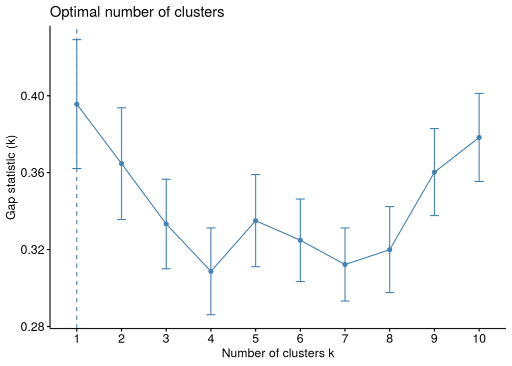

```r
fviz_nbclust(Data2007[,-c(1,2)], pam,diss=g.dist,method = "gap_stat",k.max = 10,verbose = F)
```

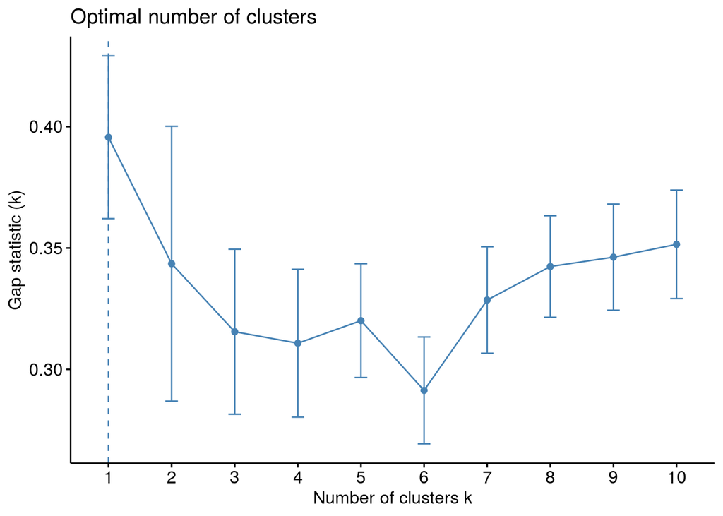

```r
fviz_nbclust(Data2007[,-c(1,2)], hcut,diss=g.dist,method = "gap_stat",k.max = 10,verbose = F)
```

#ahora con la data 2017

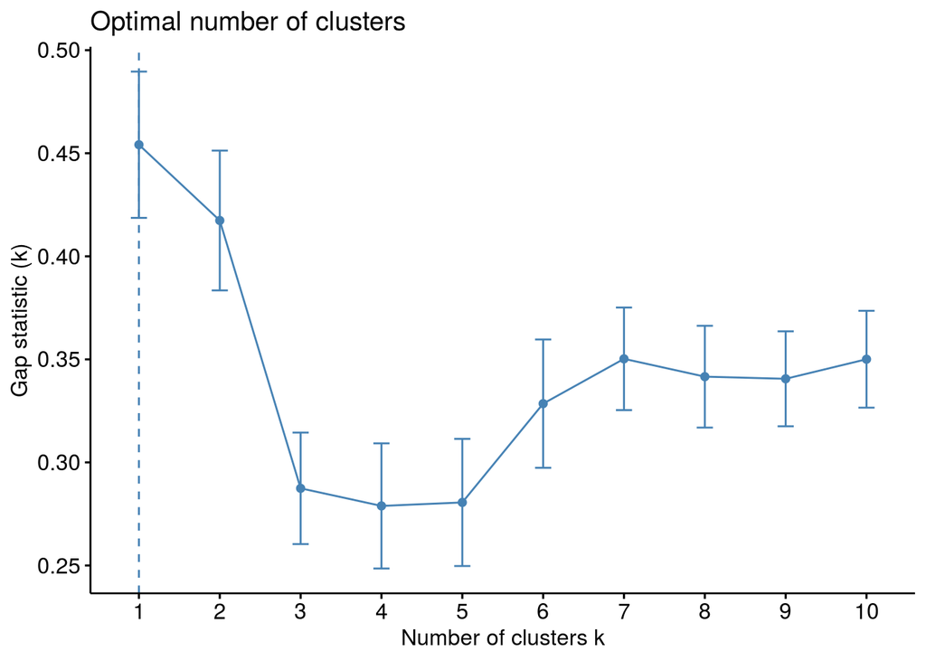

```r
fviz_nbclust(Data2017[,-c(1,2)], pam,diss=g.dist,method = "gap_stat",k.max = 10,verbose = F)
```

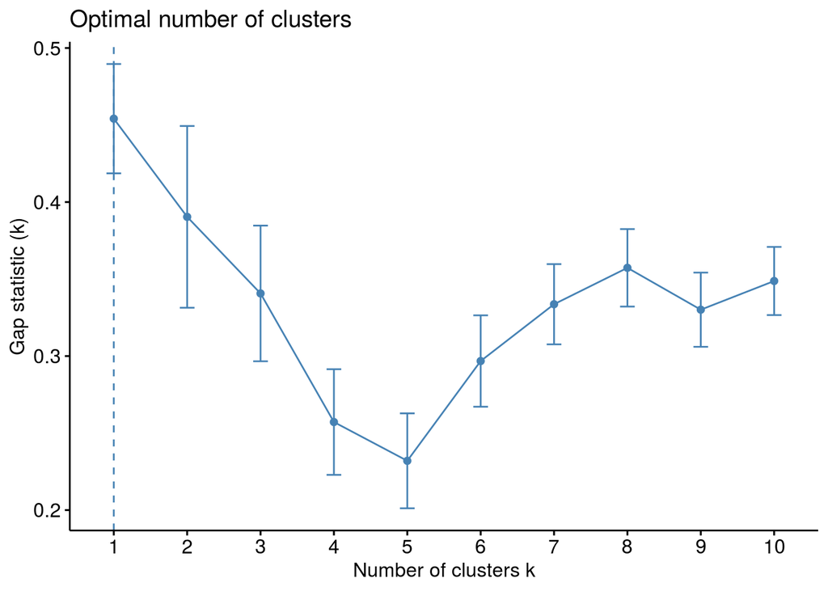

```r
fviz_nbclust(Data2017[,-c(1,2)], hcut,diss=g.dist,method = "gap_stat",k.max = 10,verbose = F)
```

Conglomeración por densidad

```r
proyeccion2007 = cmdscale(g.dist2007, k=2,add = T)
proyeccion2017 = cmdscale(g.dist2017, k=2,add = T)
```

```r
Data2007$dim1=proyeccion2007$points[,1]
Data2007$dim2=proyeccion2007$points[,2]
```

```r
Data2017$dim1=proyeccion2017$points[,1]
Data2017$dim2=proyeccion2017$points[,2]
```

```r
g.dist.cmd2007 = daisy(Data2007[,c('dim1','dim2')], metric = 'euclidean')
g.dist.cmd2017 = daisy(Data2017[,c('dim1','dim2')], metric = 'euclidean')
```

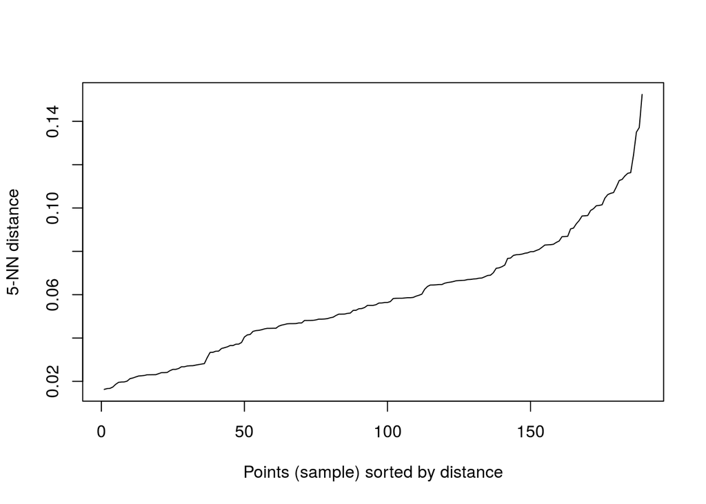

```r
library(dbscan)
kNNdistplot(g.dist.cmd2007, k=5)
```

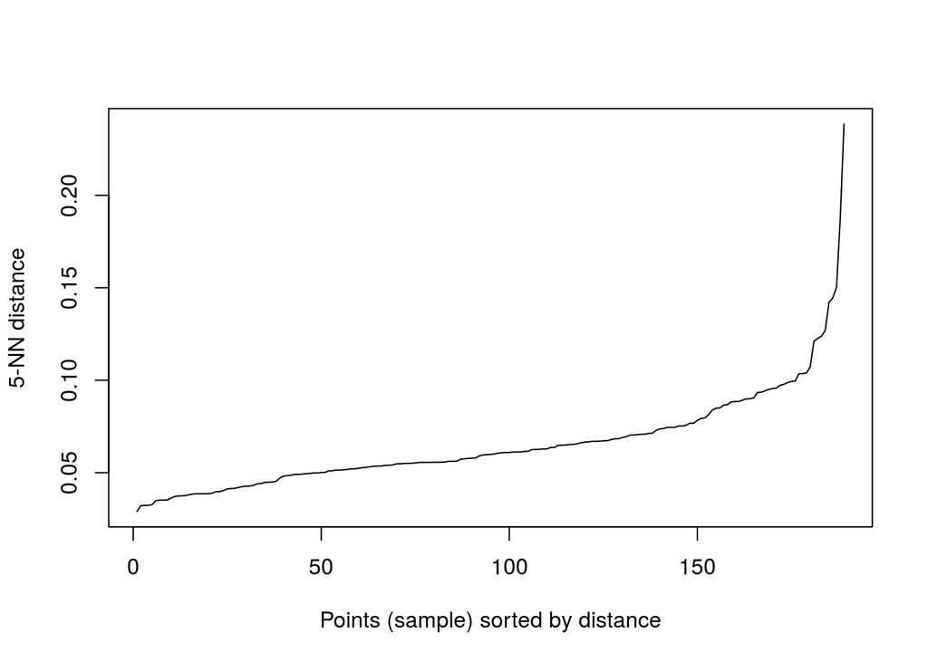

```r
kNNdistplot(g.dist.cmd2017, k=5)
```

```r
library(fpc)
db.cmd2007 = dbscan(g.dist.cmd2007, eps=0.12, MinPts=7,method = 'dist')
db.cmd2017 = dbscan(g.dist.cmd2017, eps=0.13, MinPts=7,method = 'dist')
```

```r
Data2007$dbCMD=as.factor(db.cmd2007$cluster)
Data2017$dbCMD=as.factor(db.cmd2017$cluster)
```

```r
min(Data2007[,c('dim1','dim2')]); max(Data2007[,c('dim1','dim2')])
```

```
## [1] -0.4085991
```

```
## [1] 0.687475
```

```r
min(Data2017[,c('dim1','dim2')]); max(Data2017[,c('dim1','dim2')])
```

```
## [1] -0.711954
```

```
## [1] 0.4526374
```

```r
limites2007=c(-0.41,0.69)
limites2017=c(-0.71,0.45)
```

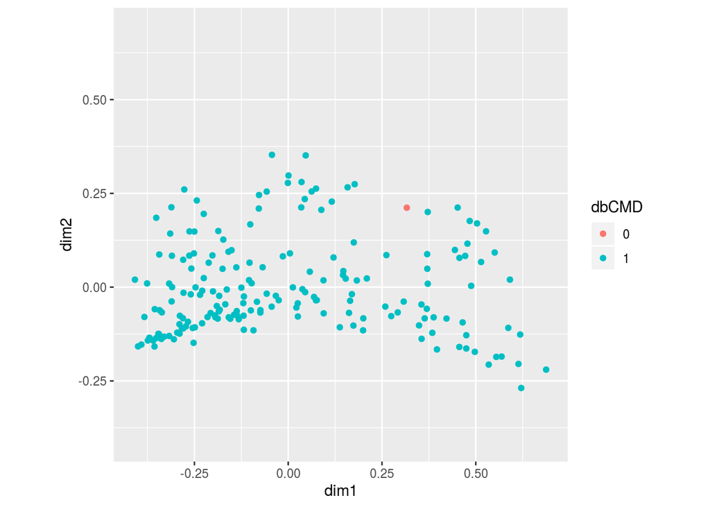

```r
library(ggrepel)
base2007= ggplot(Data2007[,-c(1,2)],aes(x=dim1, y=dim2)) + ylim(limites2007) + xlim(limites2007) + coord_fixed()
dbplot2007= base2007 + geom_point(aes(color=dbCMD))
dbplot2007
```

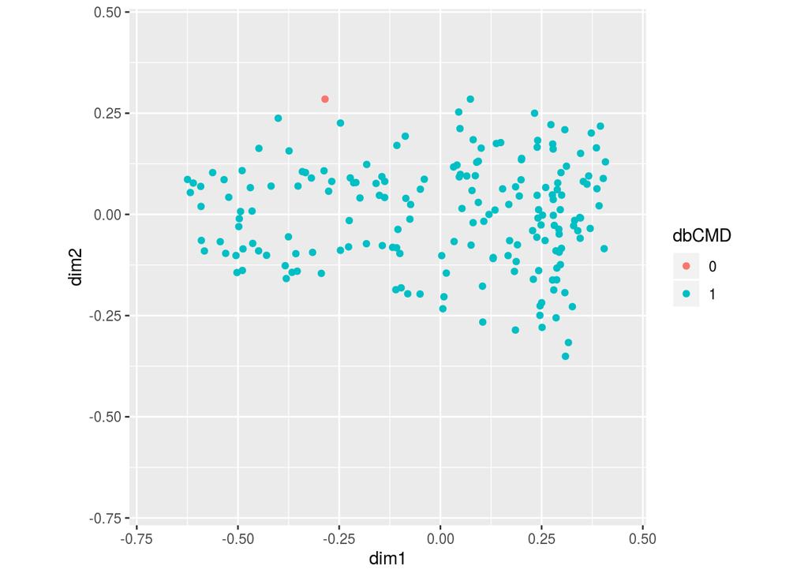

```r
base2017= ggplot(Data2017[,-c(1,2)],aes(x=dim1, y=dim2)) + ylim(limites2017) + xlim(limites2017) + coord_fixed()
dbplot2017= base2017 + geom_point(aes(color=dbCMD))
dbplot2017
```

```r
list_outliers_2007=grep('[0]{1}',Data2007$dbCMD)
list_outliers_2017=grep('[0]{1}',Data2017$dbCMD)
```

```r
rm(base2007)
rm(base2017)
rm(db.cmd2007)
rm(db.cmd2017)
rm(dbplot2007)
rm(dbplot2017)
rm(proyeccion2007)
rm(proyeccion2017)
rm(g.dist.cmd2007)
rm(g.dist.cmd2017)
rm(limites2007)
rm(limites2017)
rm(list_outliers_2007)
rm(list_outliers_2017)
Data2007=Data2007[,c(1:9)]
Data2017=Data2017[,c(1:9)]
```

siluetas de cluster 2007

```r
res.pam2007 = pam(g.dist2007,3,cluster.only = F)
res.agnes2007 = hcut(g.dist2007, k = 3,hc_func='agnes',hc_method = "ward.D")
res.diana2007 = hcut(g.dist2007, k = 3,hc_func='diana')
```

```
##   cluster size ave.sil.width
## 1       1   63          0.22
## 2       2   82          0.39
## 3       3   44          0.42
```

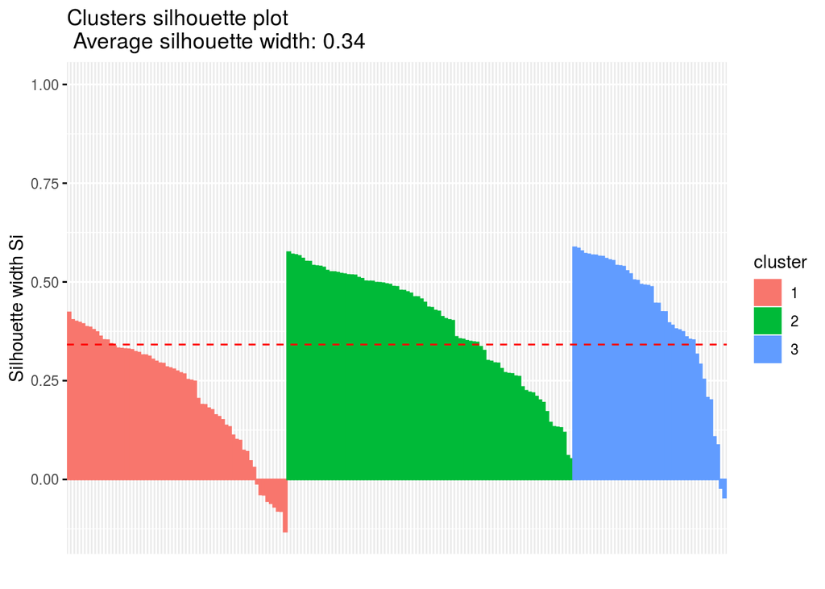

```r
fviz_silhouette(res.pam2007)
```

```
##   cluster size ave.sil.width
## 1       1   51          0.27
## 2       2   97          0.36
## 3       3   41          0.38
```

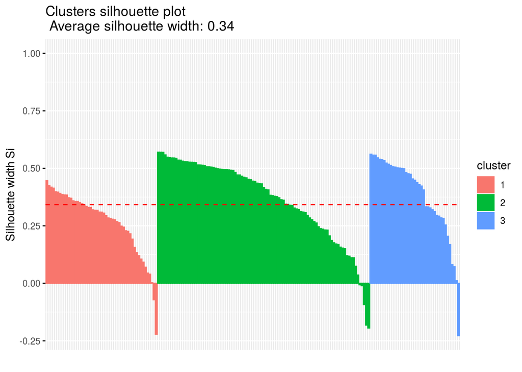

```r
fviz_silhouette(res.agnes2007)
```

```
##   cluster size ave.sil.width
## 1       1   31          0.27
## 2       2  130          0.36
## 3       3   28          0.29
```

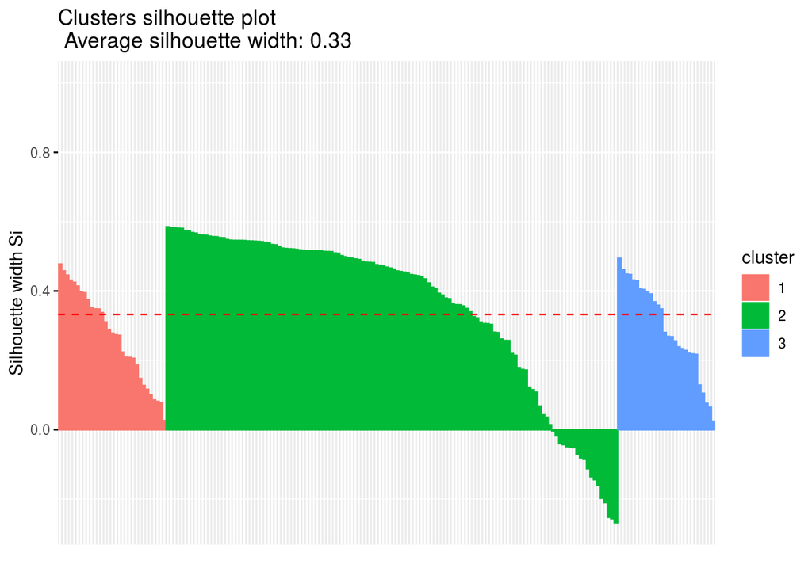

```r
fviz_silhouette(res.diana2007)
```

Siluetas para conglomeración 2017

```r
res.pam2017 = pam(g.dist2017,3,cluster.only = F)
res.agnes2017 = hcut(g.dist2017, k = 3,hc_func='agnes',hc_method = "ward.D")
res.diana2017 = hcut(g.dist2017, k = 3,hc_func='diana')
```

```
##   cluster size ave.sil.width
## 1       1   54          0.38
## 2       2   57          0.13
## 3       3   78          0.33
```

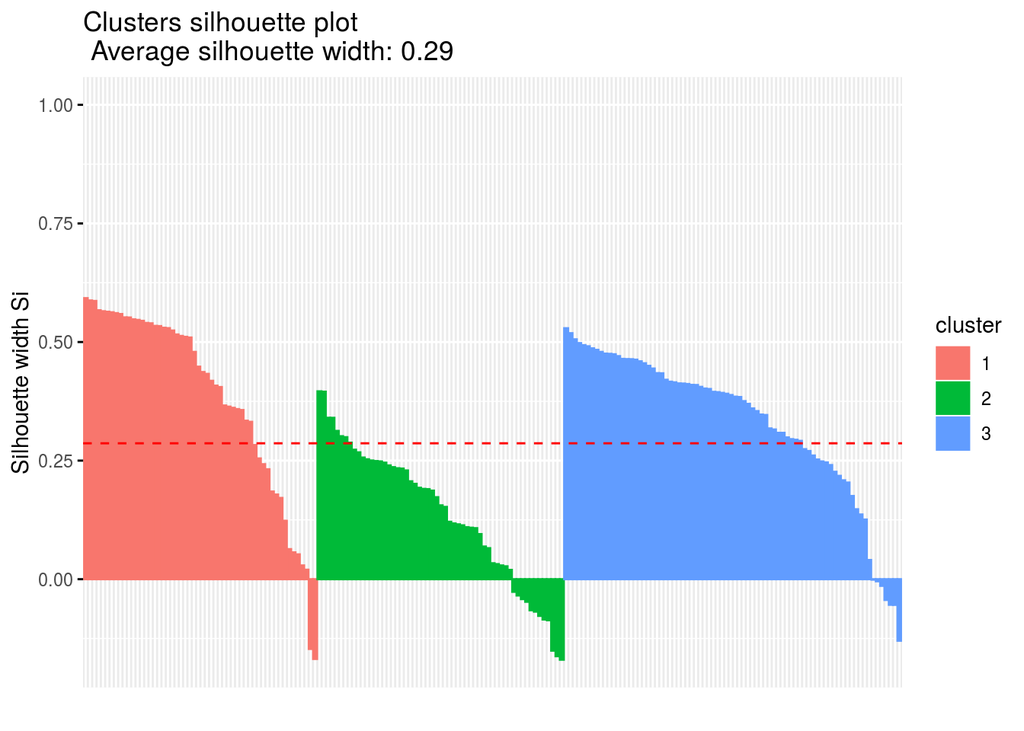

```r
fviz_silhouette(res.pam2017)
```

```
##   cluster size ave.sil.width
## 1       1   63          0.16
## 2       2   87          0.40
## 3       3   39          0.41
```

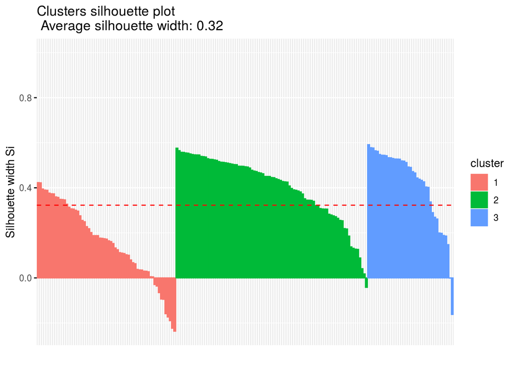

```r
fviz_silhouette(res.agnes2017)
```

```
##   cluster size ave.sil.width
## 1       1   39          0.30
## 2       2  119          0.37
## 3       3   31          0.35
```

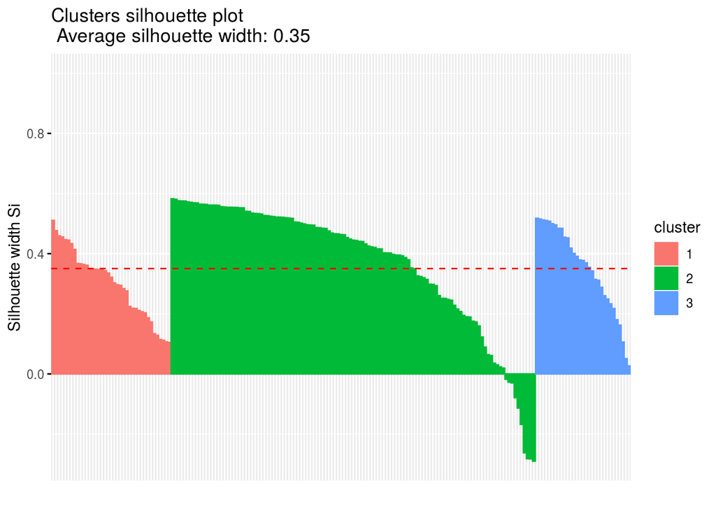

```r
fviz_silhouette(res.diana2017)
```

```r
Data2007$ClusterDI=res.diana2007$cluster
Data2017$ClusterDI=res.diana2017$cluster
```

```r
rm(res.agnes2007)
rm(res.agnes2017)
rm(res.diana2007)
rm(res.diana2017)
rm(res.pam2007)
rm(res.pam2017)
rm(g.dist2007)
rm(g.dist2017)
```

#Viendo regresiones

```r
names(Data2007)
```

```
##  [1] "Code"        "Prov_Name"   "Urb_Porc"    "Inter_Porc"  "LifeHope"
##  [6] "CompSecEdu"  "EduYears"    "IncFamPPC"   "VOTODERECHA" "ClusterDI"
```

```r
names(Data2017)
```

```
##  [1] "Code"        "Prov_Name"   "Urb_Porc"    "Inter_Porc"  "LifeHope"
##  [6] "CompSecEdu"  "EduYears"    "IncFamPPC"   "VOTODERECHA" "ClusterDI"
```

```r
modelo=formula(VOTODERECHA~ Urb_Porc + Inter_Porc + LifeHope + CompSecEdu + EduYears + IncFamPPC)
```

```r
library(stargazer)
reg2007=lm(modelo,data=Data2007)
stargazer(reg2007,type = "html",intercept.bottom = FALSE)
```

|  | *Dependent variable:* |
| --- | --- |
|  | VOTODERECHA |
| Constant | -52.423* |
|  | (26.880) |
| Urb_Porc | 17.913*** |
|  | (6.516) |
| Inter_Porc | 1.058* |
|  | (0.626) |
| LifeHope | 0.925** |
|  | (0.398) |
| CompSecEdu | -0.187** |
|  | (0.080) |
| EduYears | 1.897 |
|  | (1.234) |
| IncFamPPC | -0.080*** |
|  | (0.024) |
| Observations | 189 |
| R<sup>2</sup> | 0.107 |
| Adjusted R<sup>2</sup> | 0.078 |
| Residual Std. Error | 10.284 (df = 182) |
| F Statistic | 3.646*** (df = 6; 182) |
| *Note:* | p<0.1; p<0.05; p<0.01 |

```r
summary(reg2007)
```

Call: lm(formula = modelo, data = Data2007)

Residuals: Min 1Q Median 3Q Max -13.965 -7.243 -2.878 5.133 40.151

Coefficients: Estimate Std. Error t value Pr(>|t|)  
(Intercept) -52.42348 26.88027 -1.950 0.05268 . Urb_Porc 17.91259 6.51586 2.749 0.00658 Inter_Porc 1.05791 0.62576 1.691 0.09263 . LifeHope 0.92540 0.39785 2.326 0.02112 * CompSecEdu -0.18673 0.08003 -2.333 0.02072 * EduYears 1.89747 1.23390 1.538 0.12584  
IncFamPPC -0.07992 0.02450 -3.262 0.00132 — Signif. codes: 0 ‘**’ 0.001 ’**’ 0.01 ’’ 0.05 ‘.’ 0.1 ’ ’ 1

Residual standard error: 10.28 on 182 degrees of freedom Multiple R-squared: 0.1073, Adjusted R-squared: 0.07788 F-statistic: 3.646 on 6 and 182 DF, p-value: 0.001925

```r
library(stargazer)
reg2017=lm(modelo,data=Data2017)
stargazer(reg2017,type = "html",intercept.bottom = FALSE)
```

|  | *Dependent variable:* |
| --- | --- |
|  | VOTODERECHA |
| Constant | -24.718** |
|  | (11.568) |
| Urb_Porc | 2.391 |
|  | (4.445) |
| Inter_Porc | 0.327 |
|  | (14.792) |
| LifeHope | 0.520*** |
|  | (0.159) |
| CompSecEdu | -0.092 |
|  | (0.077) |
| EduYears | -0.629 |
|  | (1.129) |
| IncFamPPC | 0.011 |
|  | (0.008) |
| Observations | 189 |
| R<sup>2</sup> | 0.117 |
| Adjusted R<sup>2</sup> | 0.088 |
| Residual Std. Error | 9.500 (df = 182) |
| F Statistic | 4.008*** (df = 6; 182) |
| *Note:* | p<0.1; p<0.05; p<0.01 |

```r
summary(reg2017)
```

Call: lm(formula = modelo, data = Data2017)

Residuals: Min 1Q Median 3Q Max -14.222 -7.157 -1.393 5.420 46.377

Coefficients: Estimate Std. Error t value Pr(>|t|)  
(Intercept) -24.718158 11.568368 -2.137 0.03396 * Urb_Porc 2.390654 4.444819 0.538 0.59134  
Inter_Porc 0.327447 14.791546 0.022 0.98236  
LifeHope 0.519717 0.158741 3.274 0.00127 ** CompSecEdu -0.092477 0.076735 -1.205 0.22971  
EduYears -0.628560 1.128746 -0.557 0.57830  
IncFamPPC 0.011261 0.007501 1.501 0.13503  
— Signif. codes: 0 ‘**’ 0.001 ’**’ 0.01 ’’ 0.05 ‘.’ 0.1 ’ ’ 1

Residual standard error: 9.5 on 182 degrees of freedom Multiple R-squared: 0.1167, Adjusted R-squared: 0.0876 F-statistic: 4.008 on 6 and 182 DF, p-value: 0.0008545

#Diagosticos de regresión 2007

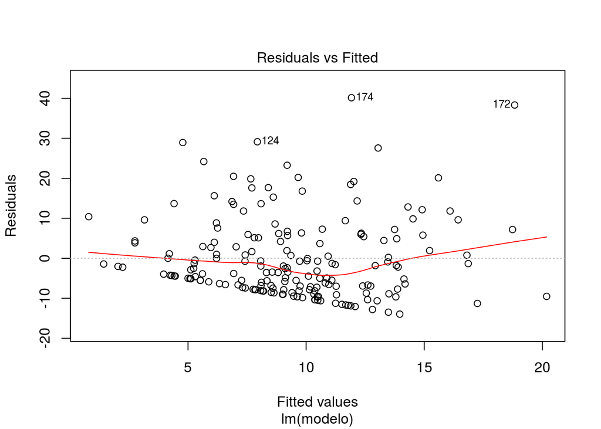

```r
#Linealidad
plot(reg2007, 1)
```

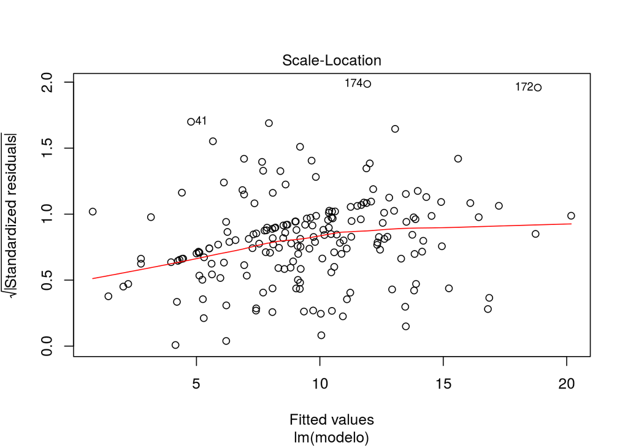

```r
#Homocedasticidad
plot(reg2007, 3)
```

```r
#Prueba Breusch-Pagan
library(lmtest)
bptest(reg2007)
```

```
##
##  studentized Breusch-Pagan test
##
## data:  reg2007
## BP = 8.373, df = 6, p-value = 0.212
```

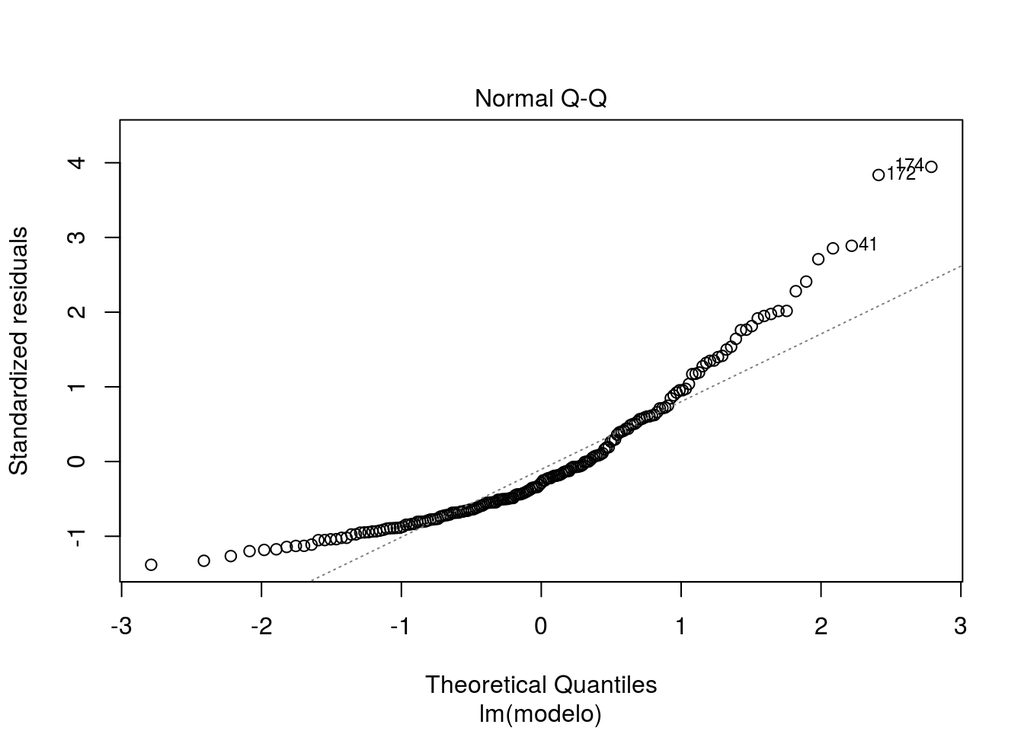

```r
#Normalidad de los residuos
plot(reg2007, 2)
```

```r
#shapiro test a residuos
shapiro.test(reg2007$residuals)
```

```
##
##  Shapiro-Wilk normality test
##
## data:  reg2007$residuals
## W = 0.88314, p-value = 5.778e-11
```

```r
#No multicolinealidad
library(DescTools)
VIF(reg2007) # > 5 es problematico
```

```
##   Urb_Porc Inter_Porc   LifeHope CompSecEdu   EduYears  IncFamPPC
##   4.629832   3.266606   1.766516   3.564777   9.133946   8.875112
```

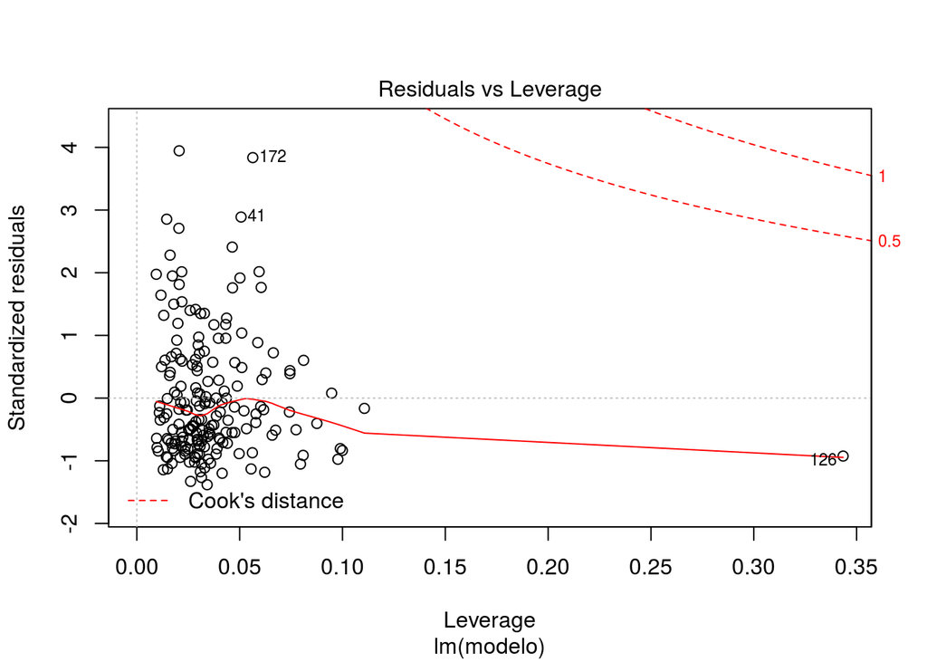

```r
#Valores influyentes
plot(reg2007, 5)
```

#Diagnósticos de regresión 2017

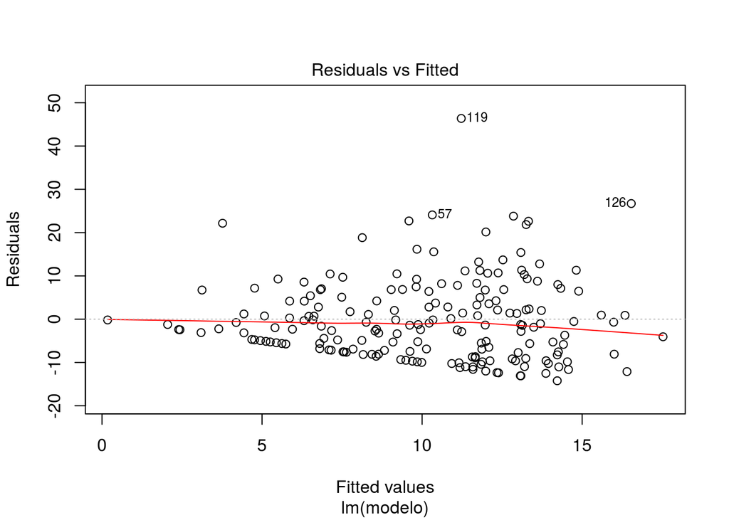

```r
#Linealidad
plot(reg2017, 1)
```

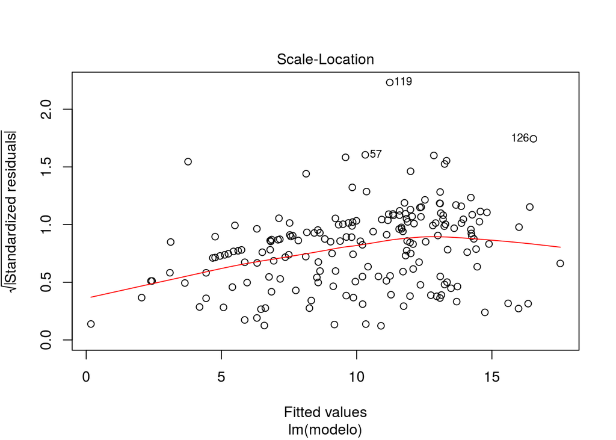

```r
#Homocedasticidad
plot(reg2017, 3)
```

```r
#Prueba Breusch-Pagan
library(lmtest)
bptest(reg2017)
```

```
##
##  studentized Breusch-Pagan test
##
## data:  reg2017
## BP = 15.771, df = 6, p-value = 0.01504
```

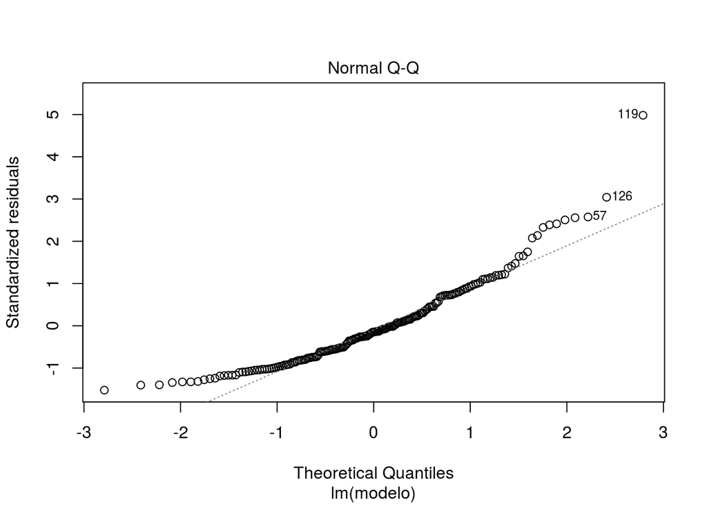

```r
#Normalidad de los residuos
plot(reg2017, 2)
```

```r
#shapiro test a residuos
shapiro.test(reg2017$residuals)
```

```
##
##  Shapiro-Wilk normality test
##
## data:  reg2017$residuals
## W = 0.91876, p-value = 1.006e-08
```

```r
#No multicolinealidad
library(DescTools)
VIF(reg2017) # > 5 es problematico
```

```
##   Urb_Porc Inter_Porc   LifeHope CompSecEdu   EduYears  IncFamPPC
##   3.770459   4.731478   1.288058   4.093583   8.766855   5.513114
```

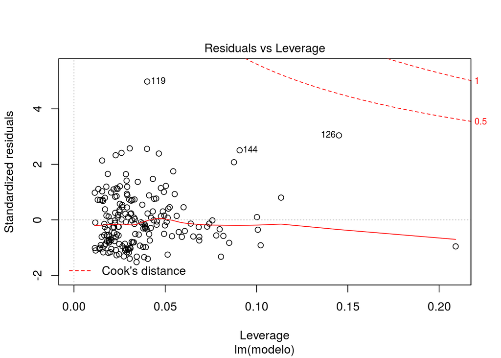

```r
#Valores influyentes
plot(reg2017, 5)
```